# Reproducible Research: Peer Assessment 1

Vlad Fridkin

January 6, 2016

## Loading and preprocessing the data

Assuming the data *activity.csv* is in the same directory, load the data into **activity** and then convert the date:

```r
activity <- read.csv("activity.csv")
activity$date <- as.Date(activity$date, "%Y-%m-%d")
```

## What is mean total number of steps taken per day?

In preparation, remove observations with NA and store in **activity2**, then check no NA values remain:

```r
activity2 <- activity[!is.na(activity$steps),]
anyNA(activity2)
```

```
## [1] FALSE
```

To calculate the mean per day, first calculate the total number of steps taken per day. Load the *plyr* package to use function *ddply* and store the result in **stepsPerDay**:

```r
library(plyr)
stepsPerDay <- ddply(activity2, "date", summarise, steps = sum(steps))
```

### Histogram

Here the mean and median are combined with the histogram, with values in the legend:

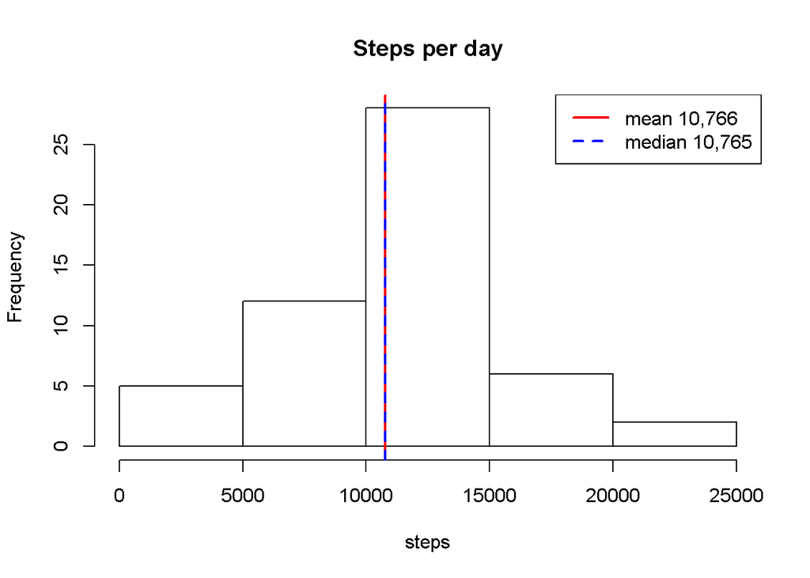

```r
s <- stepsPerDay$steps #store steps in shorthand vector s
hist(s, main = "Steps per day", xlab = "steps")
abline(v = mean(s), lwd = 2, col = "red")
abline(v = median(s), lwd = 2, lty = 2, col = "blue")

mean_s <- paste("mean", prettyNum(as.integer(mean(s)), big.mark = ","))
median_s <- paste("median", prettyNum(median(s), big.mark = ","))

legend("topright", legend = c(mean_s, median_s),
           lwd = 2, lty = c(1,2), col = c("red", "blue"))
```

### Mean and median

```r
mean_s
```

```
## [1] "mean 10,766"
```

```r
median_s
```

```
## [1] "median 10,765"
```

## What is the average daily activity pattern?

Store the average steps by interval over all days in **stepsPerIntervalAvg**. Calculate the maximum interval, steps and show together with a time series plot.

### Time series plot

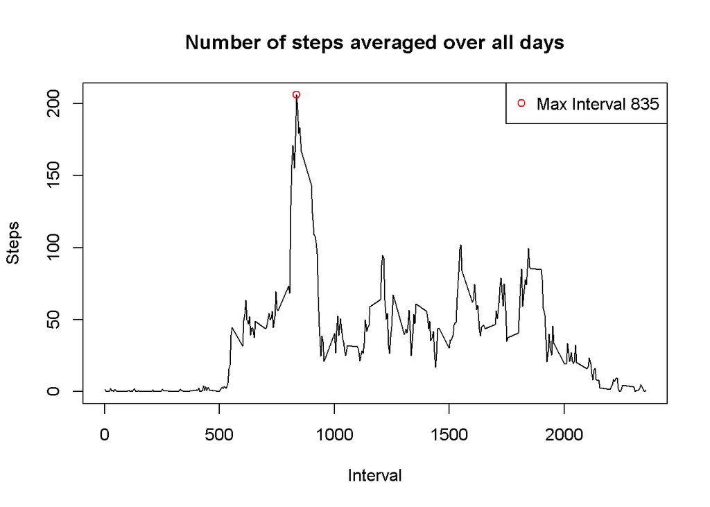

```r
stepsPerIntervalAvg <- ddply(activity2, "interval", summarise, steps = mean(steps))
maxSteps <- max(stepsPerIntervalAvg$steps)
maxInterval <- with(stepsPerIntervalAvg, interval[steps == maxSteps])
with(stepsPerIntervalAvg, {
     plot(steps~interval, type="l",
          main = "Number of steps averaged over all days", ylab = "Steps", xlab = "Interval")
})
points(maxInterval, maxSteps, pch = 1, col = "red")
legend("topright", legend = paste("Max Interval", maxInterval), pch = 1, col = "red")
```

### 5-minute interval with maximum average number of steps

```r
paste("Max Interval", maxInterval)
```

```
## [1] "Max Interval 835"
```

## Imputing missing values

The number of missing values:

```r
activityNA <- activity[is.na(activity$steps),]
nrow(activityNA)
```

```
## [1] 2304
```

### Strategy

The strategy for imputing these NA values is to use the mean for each interval contained in **stepsPerIntervalAvg** above. Specifically

1. merge stepsPerIntervalAvg with activityNA into **merged**
2. restructure **merged** for row bind with **activity2**
3. row bind into **activity3**
4. check **activity3** has the same dimensions as **activity** and contains no NA values

For the restructure (2) load package *dplyr*.

```r
library(dplyr)
merged <- merge(stepsPerIntervalAvg, activityNA,by.x = "interval", by.y = "interval") #1
merged <- select(merged, steps=steps.x, date, interval) #2
activity3 <- rbind(activity2, merged) #3
identical(dim(activity3),dim(activity)) #4a Check same dimensions as activity
```

```
## [1] TRUE
```

```r
anyNA(activity3) #4b Check if contains NA values
```

```
## [1] FALSE
```

### Histogram

The histogram, mean and median of steps per day for **activity3** follows the same process as for **activity2**.

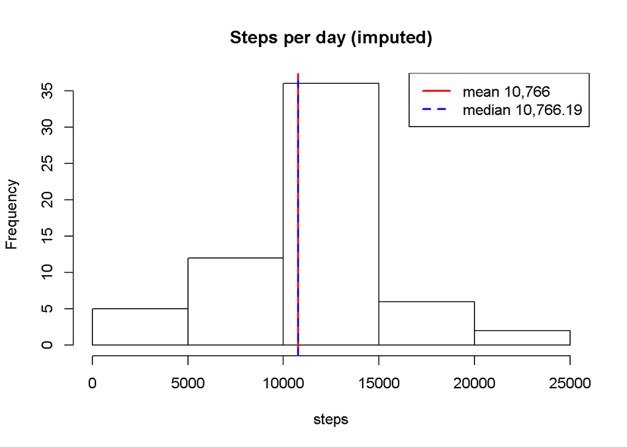

```r
stepsPerDay <- ddply(activity3, "date", summarise, steps = sum(steps))
s <- stepsPerDay$steps #store steps in shorthand vector s
hist(s, main = "Steps per day (imputed)", xlab = "steps")
abline(v = mean(s), lwd = 2, col = "red")
abline(v = median(s), lwd = 2, lty = 2, col = "blue")

mean_s <- paste("mean", prettyNum(as.integer(mean(s)), big.mark = ","))
median_s <- paste("median", prettyNum(median(s), big.mark = ","))

legend("topright", legend = c(mean_s, median_s),
           lwd = 2, lty = c(1,2), col = c("red", "blue"))
```

### Comparison with first histogram

The mean and median have not changed significantly, indicating a balanced spread of intervals with NA. The frequencies have increased due to the involvement of additional intervals that were NA previously.

## Are there differences in activity patterns between weekdays and weekends?

Use function *weekdays* to add a new factor variable to **activity3**

```r
activity3$weekday <- ifelse(weekdays(activity3$date) %in% c("Saturday", "Sunday"), "weekend", "weekday")
```

### Panel plot

To create a lattice plot, load *lattice*

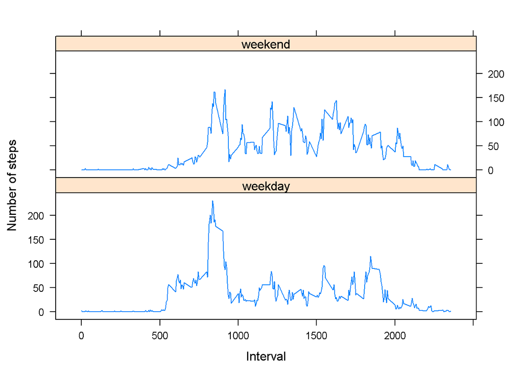

```r
library(lattice)
stepsPerDay <- ddply(activity3, c("weekday","interval"), summarise, steps = mean(steps))
xyplot(steps~interval|weekday, stepsPerDay, type = "l", ylab = "Number of steps", xlab = "Interval", layout = c(1,2) )
```

### Conclusion

There are a number of seemingly interesting patterns:

1. There is more consistent activity in daylight hours during weekends compared to weekdays. This might be explained by people being randomly active during weekends, whereas during weekdays this is contrained in working hours for sedentary jobs.
2. There is a higher peak and greater activity in the mornings for weekdays. This might be explained by people going to work during weekdays and sleeping in on the weekends.